# Course introduction and assessment

Distributed Systems · Introduction

assoc. prof. Nikola Tankovic, PhD

Faculty of Informatics, Juraj Dobrila University of Pula

## Attendance and participation

**Attendance is optional.**

If you attend, take an active part:

- Ask questions.
- Compare alternatives.
- Explain your decisions.

Use the QR code on the next slide to record your presence.

[figure not shown]

## Mark your presence

[figure not shown]

http://bit.ly/rs-tu-sam

## Teaching staff and course obligations

| **Course component** | **In charge** |
| --- | --- |
| Lectures (Predavanja) | assoc. prof. Nikola Tanković, PhD |
| Practical classes (Vježbe) | Luka Blašković, mag. inf. |

**Course obligations are organised separately for lectures and practical classes.**

Follow the requirements announced for each component.

## What this course is about

**Understand the concepts. Build systems. Explain your decisions.**

- Participants, messages, and shared state
- Failures, ordering, and coordination
- Theory applied through programming

[figure not shown]

## The route through the course

| **Stage** | **Main questions** |
| --- | --- |
| Foundations and communication | Who talks to whom? What can fail? |
| Time, replication, and consensus | What happened first? What can we agree on? |
| Recovery, workflows, and scale | How do we recover and grow? |
| Security and architecture review | What guarantees can the system provide, and under which assumptions? |

## From lectures to practical work

**Project work:**

Define the problem → Propose a solution → Implement → Test and refine

[figure not shown]

## Project preparation

Be ready to use and explain:

- **Python basics:** collections, control flow, functions, modules, and classes
- **Python tools:** comprehensions, lambdas, keyword arguments, and default values
- **Concurrency:** `asyncio`, `async` / `await`, thread and process pools
- **Web services:** FastAPI, `httpx`, and Uvicorn
- **Containers and orchestration:** Docker Compose and Docker Swarm
- **Your dependencies:** package installation, requirements, and every library used in your project

## Course information and help

**Course materials**

[E-Učenje](https://moodle.srce.hr/) · [Course web page](https://ntankovic.unipu.hr/rs)

[All lectures recorded — watch the playlist](https://www.youtube.com/playlist?list=PLIeA2EYS12RVaj1GdVP4fkNrLiK5k6VD-)

**Before asking:** consult the course materials.

**Google Chat: “FIPU RS”** is the first channel for all questions. Avoid email.

[figure not shown]

## How to pass the course (BPMN)

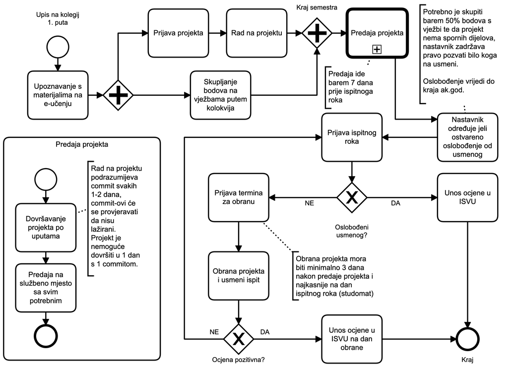

## Submission, exemption, and defence

[figure not shown]

[Book: ntankovic.unipu.hr/termin](https://ntankovic.unipu.hr/termin)

**Exemption:** ≥50% of practical points, no disputed project parts, and lecturer approval. The lecturer may still call anyone to the oral exam. Valid until the academic year ends. **Register for an exam date and note your exemption.**

## Prepare to explain your project

A useful practice checklist:

- Demonstrate the normal flow.
- Explain service boundaries and messages.
- Show what happens when something fails.
- Justify one design choice and its tradeoff.

**Practise explaining why your code behaves as it does.**

## AI use and your responsibility

**AI is allowed.** Use technologies taught in lectures or approved by the professor.

[figure not shown]

Understand **every line of code**. Defend each choice, its alternatives, and tradeoffs.

**Architecture is a set of informed choices. Prove yours.**

## Before the first technical lecture

You should know:

- Where to find the confirmed course rules and materials
- What work is expected and how it will be assessed
- Where to ask questions

Next: **a 20 MB project upload times out. Should you submit again?**